# Learning to Cross Boundaries

Motion Conceptualization in Turkish Learners of English

Aybike Canan

Aybike.Canan@vub.be

Vrije Universiteit Brussel

Ludovic De Cuypere

Ludovic.De.Cuypere@vub.be

Vrije Universiteit Brussel/Ghent University

Esli Struys

Esli.Struys@vub.be

Vrije Universiteit Brussel

## Overview

- Introduction
  - Boundary crossing events
  - Typology: S-framed vs. V-framed languages
  - Thinking for Speaking and Cross-Linguistic Influence
  - Conceptual Restructuring and Proficiency
- Research questions & Hypotheses
- Methods
  - Participants
  - Stimuli & Procedure
  - Data annotation & analysis
- Results
  - Segmentation
  - Boundary-crossing type
  - Verb type
- Discussion & Conclusion
  - Proficiency and L1 influence

# Introduction

## Boundary crossing events

Boundary-crossing (BC) events involve traversing a spatial boundary, such as entering or exiting an enclosed space (Özçalışkan 2015).

1. He ran into the house.

These events are expressed differently across languages depending on their typological profile.

## Typology: S-framed English vs. V-framed Turkish

- The expression of motion varies according to whether a language is satellite-framed (S-framed) or verb-framed (V-framed)(Talmy 2000).

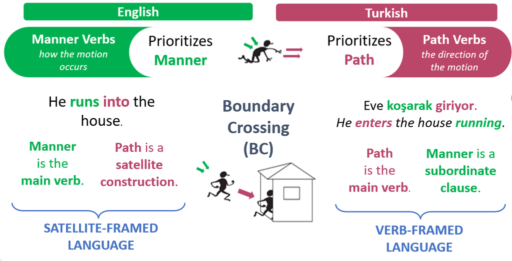

## Boundary-crossing constraint

V-languages cannot express boundary traversal using a manner verb as the main verb. Instead, they must use a path verb (Slobin & Hoiting 1994).

2. He ran into the house.
3. Eve (koşarak) girdi.

## Descriptions in Turkish vs. English

In an elicitation task documenting boundary crossing, monolingual English and Turkish adults typically produce different patterns (Özçalışkan 2015):

4. He jumps over a hurdle
5. [Koşmaya başlıyor.] [Koşarken] [karşısına bir engel çıkıyor.] [Zıplayarak **aşıyor** o engeli.] [Ondan sonra tekrar koşmasına devam ediyor]

   “[He starts running.] [As he was running,] [a hurdle comes across.] [He **crosses** the hurdle hopping from over the top of the hurdle.] [Then he continues his run again.]”

In Turkish:

- Responses are more segmented
- Crossing is expressed through a path verb
- Manner verbs are not used to overtly express crossing

## Descriptions in Turkish vs. English

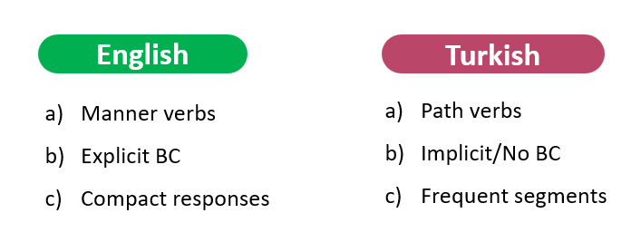

## Thinking for Speaking and Cross-Linguistic Influence

- **Thinking for speaking** (Slobin 1996): proposes that languages impose habitual *thinking patterns* that shape how events are conceptualized and expressed.
- **Cross-linguistic influence** (transfer) refers to the effect of a speaker’s L1 on L2 acquisition (Ortega 2014).

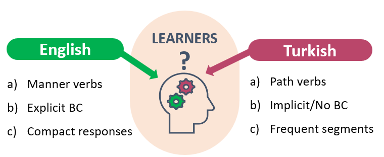

## Conceptual Restructuring and Proficiency

- Acquiring an L2 requires **conceptual restructuring**. This is a gradual shift in how learners attend to and organize events as they adopt L2-typical patterns.
- L1 influence is generally stronger at lower proficiency levels, as shown across multiple linguistic domains (Bu 2012; Hopp 2017; Wei, Zhang & Zhang 2020)
- With increased proficiency, learners begin to internalize L2-specific conceptual patterns, though this process is often incomplete.

## Conceptual Restructuring in Motion Events

- Research on motion expression shows that bilinguals and L2 learners often diverge from monolingual norms, especially when their two languages differ typologically (e.g., Brown & Gullberg 2008; 2010; 2011; Cadierno 2004; 2012; Alonso 2013; 2016; 2020).

# Research questions & Hypotheses

## Research questions

**RQ1:** How do Turkish learners of English differ from Turkish and English monolingual speakers in their expression of boundary-crossing events, particularly with respect to:

- the degree of **segmentation** in their descriptions (number of segments)
- the **explicitness of boundary traversal** (implicit vs. explicit)
- the **type of verb** employed to encode motion (manner vs. path)

**RQ2:** To what extent can the observed differences between intermediate and advanced learners be attributed to their level of L2 proficiency?

## General expectations

- Bilingual speakers: hybrid pattern in between Turkish and English
- Higher proficiency: convergence toward English-like patterns

## Hypotheses

- **Segmentation:** Because of the 10-second time limit, both groups are expected to produce minimally segmented responses.
- **Boundary crossing type:** Learners are expected to express crossing implicitly or omit it altogether due to entrenched L1 Turkish patterns.
- **Type of Verb:** Intermediate learners are expected to use more path verbs like Turkish speakers, whereas advanced learners are expected to use more manner verbs like English monolinguals.

# Methods

## Participants (N = 50)

- Turkish monolingual speakers (n = 15)
- Intermediate Turkish learners of English (n = 10)
- Advanced Turkish learners of English (n = 13)
- English monolingual speakers (n = 12).

## Participants (N = 50)

- Age range: 18 to 73 years (Median = 26).
- 35 females (70%) vs. 15 males (30%)
- Most participants were highly educated (esp. Advanced learners).
- Monolingual Turkish group included several participants with only primary or secondary schooling.

## Stimuli

- Adapted from Özçalışkan (2015)
- N = 12
- still images depicting human figures performing motion events that involved crossing a spatial boundary

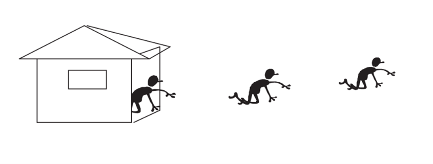

Visual stimulus depicting Adam crawling out of a house

## Procedure

- Online - Powerpoint - Zoom
- Two subsequent phases (variable “Condition”):
  - Free description: “Describe what the figure is doing in one or a few sentences within 10 seconds.”
  - Plus-verb condition: “Describe what the figure is doing using the word provided to you, in one or a few sentences within 10 seconds.”

## Data annotation: Segmentation

6. [Adam is running] [and then hurtling a green hurdle] [before continuing to run afterwards]

## Data annotation: Expression of boundary traversal

- “Explicit”: if response contained a syntactic boundary marker (e.g., *into*, *out of*, or *over*), or a verb encoding traversal inherently (e.g., *enter*, *exit*, or *cross*).
- “No/Implicit”: if the traversal was implied without explicit lexical or syntactic marking.
- Examples:
7. He runs into his house. (Explicit)
8. He runs to his house. (no overt crossing = No/Implicit)
9. He runs. (no overt crossing = No/Implicit)
10. He runs outside, then he is inside. (implicitly conveying the crossing = No/Implicit)

## Data annotation: Type of Verb

- Only for explicit boundary crossing expressions: path vs. manner.
- Examples:
11. He enters the house running. (Path)
12. He exits the house crawling. (Path)
13. He crawls into the house. (Manner)
14. He jumps out of the house. (Manner)

# Results

## Segmentation

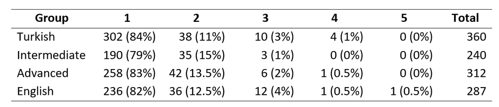

Number of segments in the responses of the participants, per Group. X² = 14.70, df = NA, P-value = 0.22; simulated P-value based on 2000 replicates).

## Boundary-crossing type

- N = 1175 responses expressing a boundary crossing event.
- N = 626 (53%): boundary crossing was implied without the use of explicit lexical or syntactic marking
- FORMULA: Type ~ Group + Condition + (1 + Condition|Participant) + (1|Item)
- Marginal R² = 20%, conditional R² = 49%

## Boundary-crossing type

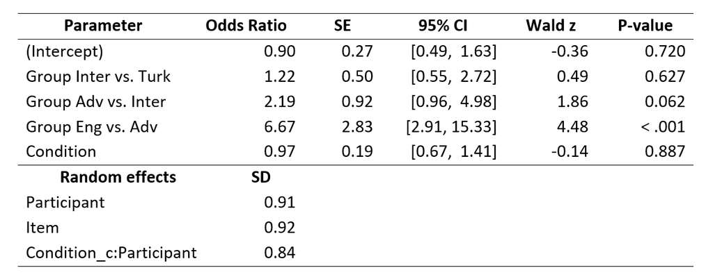

Model estimates for the effect of Group and Condition on the expression of a boundary-crossing event. Explicit was treated as the success.

## Boundary-crossing type

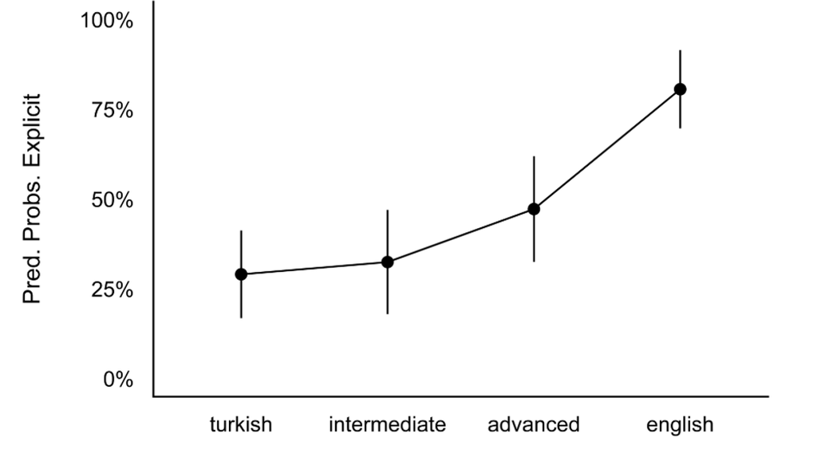

Predicted probabilities for the explicit expression of a boundary-crossing event by Group. Predicted probabilities are bias-corrected marginal means. Probabilities are conditional on average condition (i.e., condition = zero) and average Participant and Item.

## Boundary-crossing type

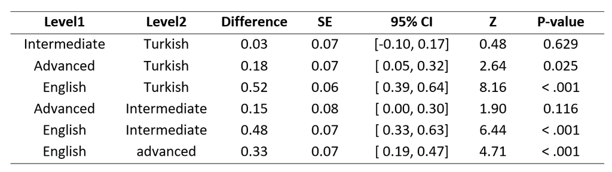

Pairwise differences between the different Groups on the probability scale. P-values are adjusted using Holm-Bonferroni.

## Verb type

- N = 549 sentences were elicited with an explicit expression of a boundary-crossing event
- N = 405 (74%), with a manner type verb.
- FORMULA: Verb ~ Group + (1|Participant) + (1|Item)
- Marginal R² = 41%, conditional R² = 76%

## Verb Type

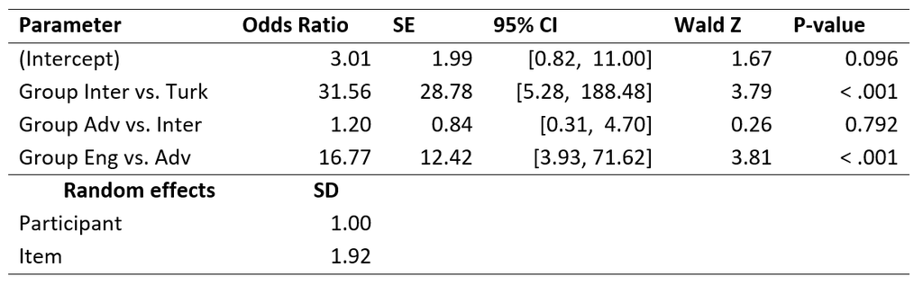

## Verb Type

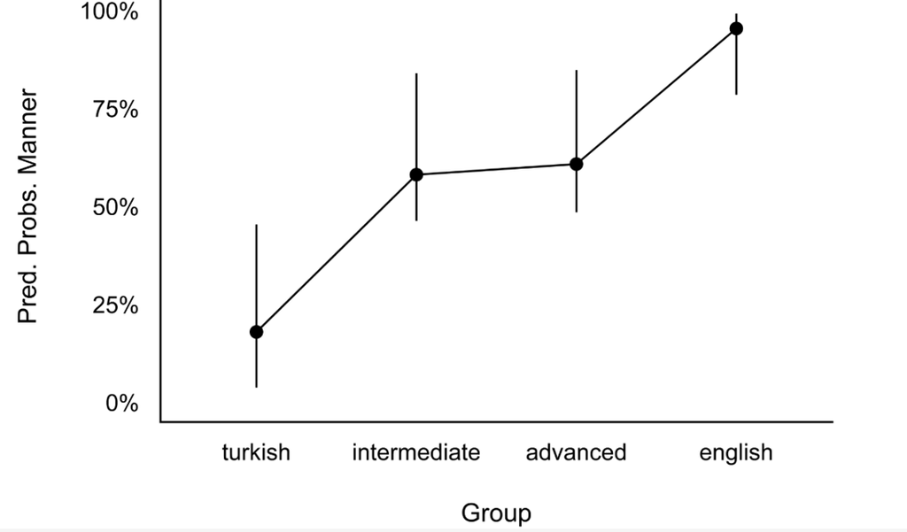

Predicted probabilities for the use of a manner verb in the explicit expression of a boundary-crossing event by Group. Predicted probabilities are bias-corrected marginal means. Probabilities are conditional on the average Participant and Item.

## Verb Type

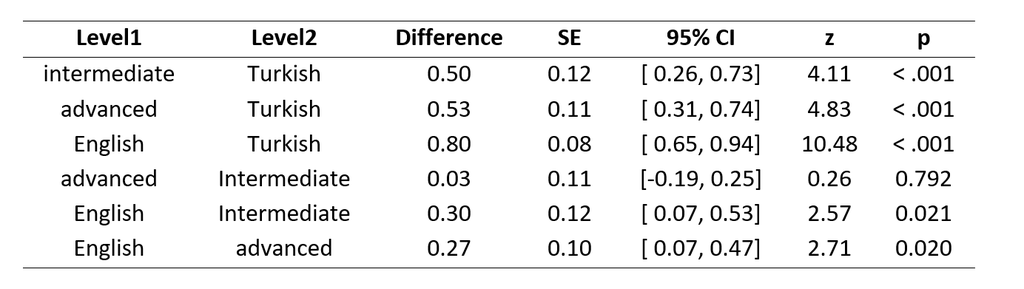

Pairwise differences between the different Groups on the probability scale. P-values are adjusted using Holm-Bonferroni.

# Discussion and Conclusion

## Proficiency and L1 influence

- Learners patterned between the two monolingual baselines, but the degree of alignment varied across lexical and syntactic levels:
  - Lexical alignment (verb type) emerged early but plateaued before reaching native-like levels.
  - Syntactic alignment (BC explicitness) progressed more slowly and, despite steady improvement, remained incomplete even at advanced levels.
  - Even at advanced proficiency, learners remained significantly distant from native-like patterns.
- The boundary crossing constraint did not transfer to L2 output literally: learners rarely constructed sentences such as *he is entering a house running*, but avoided explicitly marking the traversal instead.

## References

Alonso, R. 2013. Motion events in L2 acquisition: The boundary-crossing constraint in english and spanish. *US-China Foreign Language* 11. 738–750.

Alonso, R. 2020. Boundary-crossing events across languages: A study on english speakers, spanish speakers and second language learners. *Review of Cognitive Linguistics* 18. https://doi.org/10.1075/rcl.00062.alo.

Alonso, R. A. 2016. Cross-linguistic influence in the interpretation of boundary crossing events in L2 acquisition. *Review of Cognitive Linguistics* 14(1). 161–182. https://doi.org/10.1075/rcl.14.1.07alo.

Brown, A. & M. Gullberg. 2008. Bidirectional crosslinguistic influence in L1-L2 encoding of manner in speech and gesture: A study of japanese speakers of english. *Studies in Second Language Acquisition* 30(2). 225–251. https://doi.org/10.1017/S0272263108080327.

Brown, A. & M. Gullberg. 2010. Changes in encoding of path of motion after acquisition of a second language. *Cognitive Linguistics* 21. 263–286. https://doi.org/10.1515/COGL.2010.010.

Brown, A. & M. Gullberg. 2011. Bidirectional cross-linguistic influence in event conceptualization? Expressions of path among japanese learners of english. *Bilingualism: Language and Cognition* 14(1). 79–94. https://doi.org/10.1017/S1366728910000064.

Bu, J. 2012. A study of relationships between L1 pragmatic transfer and L2 proficiency. *English Language Teaching* 5(1). 32–43.

Cadierno, T. 2004. Expressing motion events in a second language: A cognitive typological perspective. In *Cognitive linguistics, second language acquisition, and foreign language teaching*, 13–50. Mouton de Gruyter. https://doi.org/10.1515/9783110199857.13.

Cadierno, T. 2012. Thinking for speaking in second language acquisition. *The encyclopedia of applied linguistics*. John Wiley & Sons, Ltd. https://doi.org/10.1002/9781405198431.wbeal1213.

Hopp, H. 2017. The processing of english which-questions in adult L2 learners: Effects of L1 transfer and proficiency. *Zeitschrift Für Sprachwissenschaft* 36(1). 107. https://doi.org/10.1515/zfs-2017-0006.

Ortega, L. 2014. *Understanding second language acquisition*. Taylor; Francis.

Özçalışkan, Ş. 2015. Ways of crossing a spatial boundary in typologically distinct languages. *Applied Psycholinguistics* 36(2). 485–508. https://doi.org/10.1017/S0142716413000325.

Slobin, D. I. 1996. From ’thought and language’ to ’thinking for speaking.’. In *Rethinking linguistic relativity*, 96. Cambridge University Press.

Slobin, D. I. & N. Hoiting. 1994. Reference to movement in spoken and signed languages: Typological considerations. In *Annual meeting of the berkeley linguistics society*, 487–505. https://doi.org/10.3765/bls.v20i1.1466.

Talmy, L. 2000. *Toward a cognitive semantics: Concept structuring systems*. MIT Press.

Wei, X., L. J. Zhang & W. Zhang. 2020. Associations of L1-to-L2 rhetorical transfer with L2 writers’ perception of L2 writing difficulty and L2 writing proficiency. *Journal of English for Academic Purposes* 47. 100907. https://doi.org/10.1016/j.jeap.2020.100907.

# EXTRAs

## Pedagogical Implications

- **For adult learners, typological tendencies should be made explicit:** L1 like constructions or avoidance of L2 patterns are not grammatically incorrect but they are uncommon and unnatural.
- **Motion expressions should be taught contrastively:** contrastive and interactive tasks, supported by recasts that model English-like motion constructions.
- Future research should examine the effectiveness of targeted instructional strategies.

## Data & R Notebook

- Shared via TROLLing. [CLICK HERE](https://dataverse.no/previewurl.xhtml?token=f790f855-51d6-4dbf-aca8-eb3a8a6e3c31)